# Confounding and Collinearity

2025-06-12

This notebook walks through confounding and collinearity using an example involving children’s reading scores, shoe size, height, and age.

## Setup

First, we’ll load the necessary packages and generate our fake dataset of 200 children with different ages, heights, shoe sizes, and reading scores.

```r
library(tidyverse)
library(broom)

theme_set(theme_bw())

set.seed(42)

# 1. Generate data
n <- 200
df <- tibble(
  Age = runif(n, 6, 18),                # ages between 6 and 18 years
  Height = 90 + 6 * Age + rnorm(n, 0, 5),   # height increases with age
  ShoeSize = 15 + 0.4 * Height + rnorm(n, 0, 2), # shoe size correlates with height
  ReadingScore = 30 + 5 * Age + rnorm(n, 0, 10)  # reading ability increases with age
)
```

## 1. **Plot shoe size versus reading score** to visualize one of these associations:

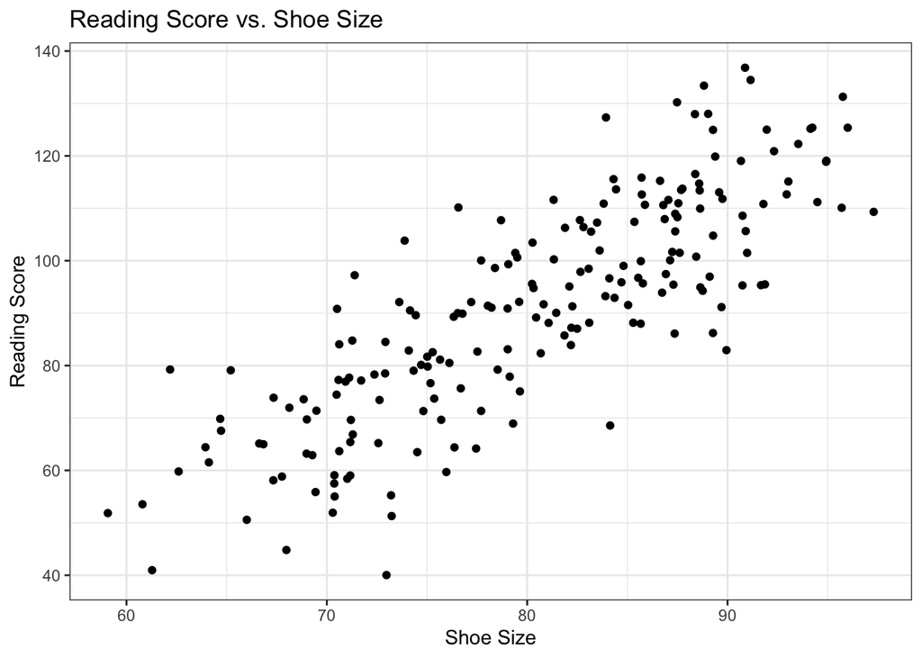

```r
# Plot: ShoeSize vs ReadingScore
ggplot(df, aes(x = ShoeSize, y = ReadingScore)) +
  geom_point() +
  labs(title = 'Reading Score vs. Shoe Size', x = 'Shoe Size', y = 'Reading Score')
```

At this point, one might (wrongly) think: “Wow, bigger shoe sizes lead to better reading!” But we haven’t accounted for age yet.

**Even looking at a simple model** shows a statistically significant relationship:

```r
model_shoe_only <- lm(ReadingScore ~ ShoeSize, data = df)
tidy(model_shoe_only)
```

```
## # A tibble: 2 × 5
##   term        estimate std.error statistic  p.value
##   <chr>          <dbl>     <dbl>     <dbl>    <dbl>
## 1 (Intercept)   -70.5     7.90       -8.93 2.94e-16
## 2 ShoeSize        2.01    0.0979     20.6  5.28e-51
```

You’ll see a positive coefficient for ShoeSize, suggesting larger shoe sizes are associated with higher reading scores. But this is misleading!

## 2. Illustrating Confounding by Age

**A confounder** influences both our predictor (shoe size) and outcome (reading score). Here, **Age** might actually account for the fact that kids both have larger feet and are better readers.

**First**, let’s **plot Age against ShoeSize**:

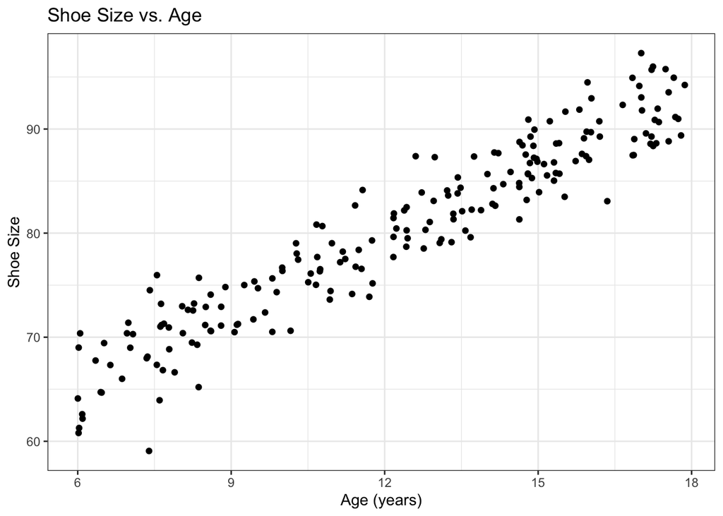

```r
ggplot(df, aes(x = Age, y = ShoeSize)) +
  geom_point() +
  labs(title = 'Shoe Size vs. Age', x = 'Age (years)', y = 'Shoe Size')
```

**Now let’s “adjust”** for Age by adding it into our regression with ShoeSize:

```r
model_adjusted <- lm(ReadingScore ~ ShoeSize + Age, data = df)
tidy(model_adjusted)
```

```
## # A tibble: 3 × 5
##   term        estimate std.error statistic  p.value
##   <chr>          <dbl>     <dbl>     <dbl>    <dbl>
## 1 (Intercept)   33.5      13.8       2.42  1.63e- 2
## 2 ShoeSize      -0.140     0.264    -0.530 5.97e- 1
## 3 Age            5.59      0.650     8.61  2.35e-15
```

You’ll see that once Age is included, the effect of ShoeSize often shrinks or vanishes. This shows how confounding can produce a **spurious correlation**.

## 3. Demonstrating Collinearity

**Let’s look** at **Height vs. ShoeSize**:

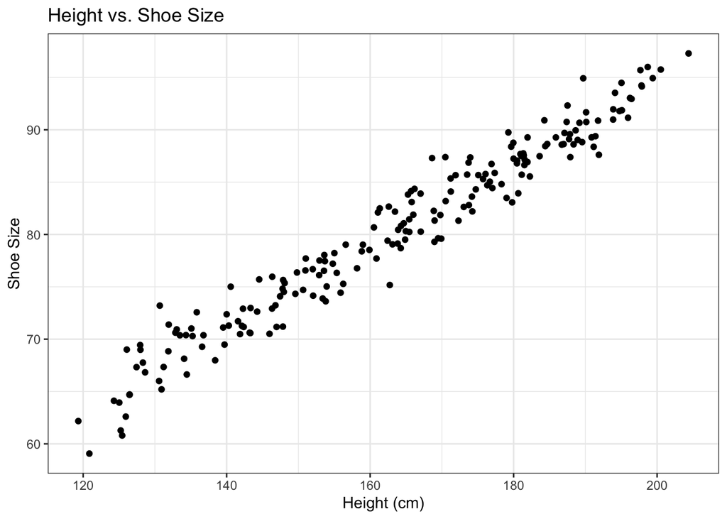

```r
ggplot(df, aes(x = Height, y = ShoeSize)) +
  geom_point() +
  labs(title = 'Height vs. Shoe Size', x = 'Height (cm)', y = 'Shoe Size')
```

**Next**, we fit a model with both ShoeSize and Height (without Age) to see the instability:

```r
model_collinear <- lm(ReadingScore ~ ShoeSize + Height, data = df)
tidy(model_collinear)
```

```
## # A tibble: 3 × 5
##   term        estimate std.error statistic    p.value
##   <chr>          <dbl>     <dbl>     <dbl>      <dbl>
## 1 (Intercept) -44.8        9.32     -4.81  0.00000301
## 2 ShoeSize      0.0742     0.425     0.175 0.862
## 3 Height        0.794      0.170     4.67  0.00000554
```

Notice how coefficient signs or their uncertainty can flip around—**an indicator of multicollinearity**.

## 4. Putting It All Together

**Finally**, we’ll include **Age**, **Height**, and **ShoeSize** in one model:

```r
model_full <- lm(ReadingScore ~ ShoeSize + Height + Age, data = df)
summary(model_full)
```

```
##
## Call:
## lm(formula = ReadingScore ~ ShoeSize + Height + Age, data = df)
##
## Residuals:
##     Min      1Q  Median      3Q     Max
## -27.665  -6.157   0.113   7.239  33.368
##
## Coefficients:
##             Estimate Std. Error t value Pr(>|t|)
## (Intercept)  40.7009    14.7847   2.753  0.00646 **
## ShoeSize      0.2371     0.3818   0.621  0.53530
## Height       -0.2966     0.2179  -1.362  0.17490
## Age           6.4924     0.9263   7.009 3.77e-11 ***
## ---
## Signif. codes:  0 '***' 0.001 '**' 0.01 '*' 0.05 '.' 0.1 ' ' 1
##
## Residual standard error: 10.17 on 196 degrees of freedom
## Multiple R-squared:  0.7703, Adjusted R-squared:  0.7668
## F-statistic: 219.1 on 3 and 196 DF,  p-value: < 2.2e-16
```

**And then compare** all four approaches side by side:

```r
bind_rows(
  tidy(model_shoe_only)       %>% mutate(model = '1. ShoeSize only'),
  tidy(model_adjusted)                       %>% mutate(model = '2. + Age'),
  tidy(model_collinear)                      %>% mutate(model = '3. ShoeSize + Height'),
  tidy(model_full)                           %>% mutate(model = '4. Full model')
) %>%
  select(model, term, estimate, std.error, statistic, p.value) %>%
  print(n = Inf)
```

```
## # A tibble: 12 × 6
##    model                term        estimate std.error statistic  p.value
##    <chr>                <chr>          <dbl>     <dbl>     <dbl>    <dbl>
##  1 1. ShoeSize only     (Intercept) -70.5       7.90      -8.93  2.94e-16
##  2 1. ShoeSize only     ShoeSize      2.01      0.0979    20.6   5.28e-51
##  3 2. + Age             (Intercept)  33.5      13.8        2.42  1.63e- 2
##  4 2. + Age             ShoeSize     -0.140     0.264     -0.530 5.97e- 1
##  5 2. + Age             Age           5.59      0.650      8.61  2.35e-15
##  6 3. ShoeSize + Height (Intercept) -44.8       9.32      -4.81  3.01e- 6
##  7 3. ShoeSize + Height ShoeSize      0.0742    0.425      0.175 8.62e- 1
##  8 3. ShoeSize + Height Height        0.794     0.170      4.67  5.54e- 6
##  9 4. Full model        (Intercept)  40.7      14.8        2.75  6.46e- 3
## 10 4. Full model        ShoeSize      0.237     0.382      0.621 5.35e- 1
## 11 4. Full model        Height       -0.297     0.218     -1.36  1.75e- 1
## 12 4. Full model        Age           6.49      0.926      7.01  3.77e-11
```

You’ll find that **Age** remains the noteable predictor, while the apparent effects of height and shoe size weaken.

**A word of warning**: Even when we include all of three of these predictors in our model, there could be /other/ omitted variables, so it’s best to **avoid any causal conclusions**. It’s hard to tease out cause and effect from observational data alone!

## Recap of Concepts

1. **Confounder:** A variable (e.g., Age) that drives both predictor and outcome, misleading simple associations.
2. **Collinearity:** When predictors (e.g., Height & ShoeSize) correlate strongly, causing unstable coefficient estimates.
3. **Omitted Variable Bias:** Even after adjusting, unmeasured factors can still bias estimates; causal claims require rigorous design (e.g., randomization).